# 学习笔记

# 第一周：熟悉软件和流程

## 准备工作

- 注册一个[**GitHub账户https://github.com**](https://github.com)
- 安装或者更新**R**和**RStudio**
- 下载并安装特定于平台的Git。这里我安装[**Git(windows)https://gitforwindows.org/**](https://gitforwindows.org/)
- 使用全局命令配置Git。在我完成此过程时，我发现这一步是必要的。打开 bash 版本的 Git 并输入以下内容：

`git config --global user.name 'leimingri'`

`git config --global user.email 'lmr18845128812@163.com'`

`git config --global --list`

替换您的名称和与GitHub帐户相关的电子邮件

- 已确认可以从命令行对GitHub推/拉

## 连接Git GitHub,RStudio

这部分主要概述让RStudio与GitHub一起工作的简单步骤。首先您必须了解与 Git 相关的四个术语：存储库、提交、推送和拉取，打开Rstudio并设置Git可执行文件的路径*Tools > global options > Git/SVM*。首先，在GitHub上面创建一个项目repository，然后将项目地址克隆到RStudio中，接着进行本地的更改、保存及提交，将新增更改的内容保存到GitHub该项目存储库中。

- 连接RStudio到Git和GitHub

在GitHub上创建存储库（项目）,然后通过RStudio将新的GitHub存储库克隆到您的计算机上，这就是Rstudio如何知道要使用什么存储库，并将其与您的新存储库相关联项目文件。在RStudio中，*File > New Project > Version Control > Git*。

[figure not shown]

[figure not shown]

[figure not shown]

[figure not shown]

- 进行本地更改，保存、提交

现在在新的R项目中做一些工作，创建并保存一些文件。下一步是“提交”您的工作——本质上是复制您所有的脚本文件与R项目相关联。接着*Tools>Version Control>Commit*将您在本地进行的更改在线推送到GitHub。

[figure not shown]

- 确认传播到GitHub远程存储器的本地更改

[figure not shown]

检查想要提交的文件，然后按下**Commit**按钮。如果想把这些文件移到GitHub服务器上，点击“Push”。在线查看您的存储库，仔细检查您的文件是否确实在那里。

注：[R Markdown官网地址http://rmarkdown.rstudio.com](http://rmarkdown.rstudio.com)  
以上内容参考文献[happy-git-with-R](https://happygitwithr.com/)

## Debugging

1.错误: LaTeX failed to compile R.tex.

解决办法：[链接https://yihui.org/tinytex/r/#debugging for debugging tips.](https://yihui.org/tinytex/r/#debugging%20for%20debugging%20tips.)—有时候是插入的图片问题

2.导入GitHub中的URL时，出现‘…Connection was reset, errno 10054’错误时

解决办法：`git config --global http.sslVerify` “false”即解除ssl验证，再次git即可

3.第一次点选Knit PDF（或Knit HTML)报错Knit PDF : pandoc document conversion failed with error 43

解决办法：可以通过安装 github 上最新的版本解决：  
`install.packages(“devtools”)`  
如果以前没有安装 devtools 包  
`devtools::install_github(“rstudio/rmarkdown”)`

4.错误：PDF中文问题

latex_engine: xelatex（尝试加上这句话）

5.错误：导入GitHub中的URL时，出现‘…Connection was reset, errno 10054’错误

解决办法：git bash里面`git config --global http.sslVerify "false"`即解除ssl验证，再次git

*针对上面的错误，注意：可以多多尝试*

方法一：用压缩的方式进行下载  
`git config --global --add core.compression -1`

方法二：.增大缓存大小  
524288000表示增至500兆，1048576000表示增至1G  
`git config --global http.postBuffer 524288000`

方法三：利用ssh下载  
`git clone git://github.com/XX/XXXX.git`

方法四：安全设置问题  
`git config http.sslVerify "false"`

# 第二周：利用Rmarkdown制作简历，学习ggplot2

## 简历相关资料借鉴

| 一些简历资源 | 链接 |
| --- | --- |
| 简历学习模板1 | https://github.com/geekcompany/DeerResume |
| 简历学习模板2 | https://github.com/geekcompany/ResumeSample |
| 在线MarkDown简历书写工具 冷熊简历 | http://link.ftqq.com/0rsRL |
| 教学：《如何写好技术简历》 | http://link.ftqq.com/KWkVX |
| 简历例句 | https://github.com/resumejob/awesome-resume |
| 大厂高频面经面试题 | https://osjobs.net/topk/ |

## ggplot2绘图入门

### 导论

#### <基本概念>

- 图层（Layer）：图层可以允许用户一步步的构建图形，方便单独对图层进行修改、增加统计量、甚至改动数据。
- 标度（Scale）：标度是一种函数，它控制了数学空间到图形元素空间的映射。一组连续数据可以映射到X轴坐标，也可以映射到一组连续的渐变色彩。一组分类数据可以映射成为不同的形状，也可以映射成为不同的大小。
- 坐标系统（Coordinate）：坐标系统控制了图形的坐标轴并影响所有图形元素，最常用的是直角坐标轴，坐标轴可以进行变换以满足不同的需要，如对数坐、极坐标轴。
- 位面（Facet）：很多时候需要将数据按某种方法分组，分别进行绘图。位面就是控制分组绘图的方法和排列形式。

#### <一个例子>

用ggplot2包内带的汽车测试数据（mpg）来举个例子，用到的三个变量分别是发动机容量(displ)、高速公路上的每加仑行驶里数(hwy)、汽缸数目(cyl)。首先加载ggplot2包，然后用ggplot定义第一层即数据来源。其中aes参数非常关键，它将displ映射到X轴，将hwy映射到Y轴，将cyl变为分类数据后映射为不同的颜色。然后使用+号添加了两个新的图层，第二层是加上了散点，第三层是加上了loess平滑曲线。

```r
install.packages("ggplot2")
```

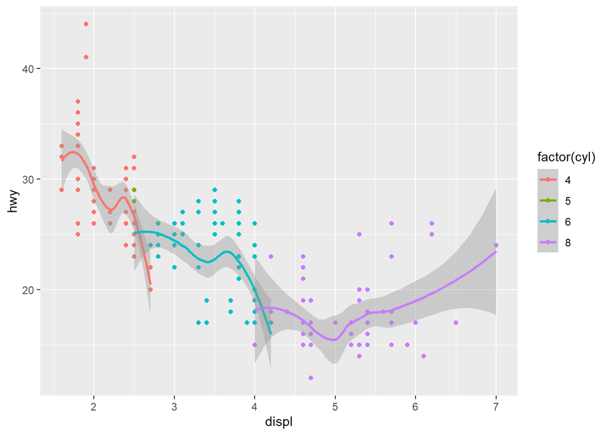

```r
library(ggplot2)
p <- ggplot(data=mpg,aes(x=displ,y=hwy,colour=factor(cyl)))
p + geom_point() + geom_smooth()
```

如果需要对整体数据进行平滑，可将colour参数设置在散点图层内而非第一层，这样第三层的平滑图形就不会受到colour参数的影响。

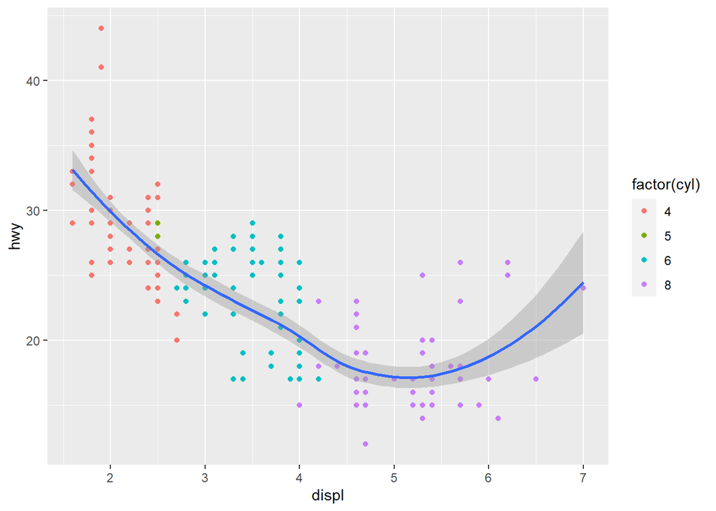

```r
p <- ggplot(mpg,aes(x=displ,y=hwy))
p + geom_point(aes(colour=factor(cyl))) + geom_smooth()
```